# Plantes estressades

PIE2

Tardor 2019-2020

En un estudi per veure com influeix, a primera hora del matí, l’estrès hídric sobre la fisiologia d’unes plantes, es va realitzar una experiència en la que es va mesurar la la fotosíntesi, FS, i la evapotranspiració, ET, de plantes sotmeses a un nivell d’estrès hídric, $S_1,\ldots,S_k$ del factor SHIDR amb $k = 3$ nivells d’estrès codificats. El nombre de plantes utilitzades a cada nivell d’estrès de la experiència és el mateix, 7. La forma de mesurar aquestes variables és pinçant una fulla de la planta amb un aparell que a més de mesurar les variables FS i ET, mesura altres variables com l’hora en que s’ha fet la mesura, T, la radiació solar que rep la planta en el moment de fer la mesura, R. En realitzar l’experiència, un problema va ser que fer les mesures d’una planta dura uns tres minuts i que a primera hora del mati les condicions atmosfèriques canvien ràpidament i això pot influir a la fisiologia de les plantes. Per aquest motiu s’ha aleatoritzat l’ordre en que s’han mesurat les plantes. Totes les dades (SHIDR, FS, ET, T i R) les teniu en el fitxer amb el vostre nom a Atenea (carpeta de dades del 2n entregable). Resoleu els exercicis següents suposant que es compleixen las condiciones dels models lineals, i utilitzeu un nivell de significació $\alpha = 0.05$. En el cas d’haver de comparar els nivells del factor SHIDR, utilitzeu el mètode de Tukey i si heu de fer l’ANOVA utilitzeu les sumes de quadrats de tipus 2.

*Directori de treball, llegir dades, calcular global i definir factors*

```r
setwd('.')
library(car)
library(emmeans)
library(tables)
library(RcmdrMisc)
dd<-read.csv2("input.csv")
dd$SHIDR<-as.factor(dd$SHIDR)
```

**Inicialment plantegeu, ajusteu i analitzeu el model lineal (Mod1) que explica la ET, a partir de SHIDR.**

##### 4) L’estadístic de contrast és el F-statistic o F-value (són el mateix). En general és $\frac{\text{variació explicada pel model · (k-1)}}{\text{variació no explicada pel model · (n-1)}} = \frac{R^2/(k-1)}{(1-R^2)/(n-k)}$ on n és el nombre de mostres, k és el nombre de variables (comptant l’intercept) i R és el Multiple R-squared

##### 5)El pvalor és pf(F, df.model, df.residual, lower.tail=F)

```r
mod1 <-lm(ET~SHIDR, dd)
m0 <- lm(ET~1, dd)

summary(mod1)
```

```
##
## Call:
## lm(formula = ET ~ SHIDR, data = dd)
##
## Residuals:
##     Min      1Q  Median      3Q     Max
## -2.0086 -0.9186 -0.1886  0.6714  1.9414
##
## Coefficients:
##             Estimate Std. Error t value Pr(>|t|)
## (Intercept)   3.3686     0.4273   7.884 3.01e-07 ***
## SHIDRS2       0.0100     0.6042   0.017    0.987
## SHIDRS3       0.6800     0.6042   1.125    0.275
## ---
## Signif. codes:  0 '***' 0.001 '**' 0.01 '*' 0.05 '.' 0.1 ' ' 1
##
## Residual standard error: 1.13 on 18 degrees of freedom
## Multiple R-squared:  0.08463,    Adjusted R-squared:  -0.01707
## F-statistic: 0.8321 on 2 and 18 DF,  p-value: 0.4512
```

```r
summary(mod1)$sigma^2
```

```
## [1] 1.277803
```

```r
Anova(mod1)
```

```
## Anova Table (Type II tests)
##
## Response: ET
##            Sum Sq Df F value Pr(>F)
## SHIDR      2.1266  2  0.8321 0.4512
## Residuals 23.0005 18
```

```r
pf(1.1336, 2, 18, lower.tail=F)
```

```
## [1] 0.3438023
```

**Com que fer les mesures han durat molt temps, plantegeu, contrasteu i analitzeu, el model lineal (Mod2) que explica la ET, a partir de T i R.**

##### 6) El coeficient de T és $\beta_1$, l’Estimate de T en el summary.

##### 7) La significació del coeficient de R és el pvalor quan plantegem la hipòtesis que el coeficient de R $(\beta_2) \neq 0$. Apareix en el summary i es calcula mitjançant una t-student

##### 8) Fem el test omnibus (que ve a ser comparar el nostre model amb el model nul mitjançant una anova(model, model nul)).

##### 9) Observem el F-value de l’omnibus

##### 10) El pvalor és pf(F, df.model, df.residual, lower.tail=F)

```r
mod2 <-lm(ET~T+R,  dd)

summary(mod2)
```

```
##
## Call:
## lm(formula = ET ~ T + R, data = dd)
##
## Residuals:
##      Min       1Q   Median       3Q      Max
## -0.71751 -0.27102 -0.09257  0.11242  1.05429
##
## Coefficients:
##             Estimate Std. Error t value Pr(>|t|)
## (Intercept) 1.623412   4.143467   0.392    0.700
## T           0.046484   0.115929   0.401    0.693
## R           0.001117   0.014650   0.076    0.940
##
## Residual standard error: 0.4667 on 18 degrees of freedom
## Multiple R-squared:  0.844,  Adjusted R-squared:  0.8266
## F-statistic: 48.68 on 2 and 18 DF,  p-value: 5.486e-08
```

```r
anova(mod2, m0)
```

```
## Analysis of Variance Table
##
## Model 1: ET ~ T + R
## Model 2: ET ~ 1
##   Res.Df     RSS Df Sum of Sq      F    Pr(>F)
## 1     18  3.9209
## 2     20 25.1271 -2   -21.206 48.676 5.486e-08 ***
## ---
## Signif. codes:  0 '***' 0.001 '**' 0.01 '*' 0.05 '.' 0.1 ' ' 1
```

```r
pf(2.781, 2, 18, lower.tail=F)
```

```
## [1] 0.08862233
```

##### Extra 1. Fem el test omnibus i mirem si el pvalor és significatiu

##### Extra 2. Mirem si el coeficient de T és rellevant Test Anova

##### Extra 3. Mirem si el coeficient de SHIDR és rellevant Test Anova

##### 11) Observem F-value de l’Anova per el SHIDR

##### 12) L’estimació de $Var[Error]$ és $\frac{\text{Sum Sq of Residulats}}{Df}$ del test Anova o directament summary(mod1)$sigma^2

##### 13) Hem de calcular el pendent de T donat S1 (és a dir respecte del factor SHIDR). Per això utilitzem la funció emtrends(m, ~M, var = “C”) la qual calcula els pendents de la variable C emprant el model m i respecte del factor M.

##### 14) Mirem en summary quins coeficients del SHIDR són diferents al intercept

##### 15) Fem el test omnibus i mirem si el pvalor és significatiu

```r
mod3 <-lm(ET~SHIDR+R,  dd)

summary(mod3)
```

```
##
## Call:
## lm(formula = ET ~ SHIDR + R, data = dd)
##
## Residuals:
##      Min       1Q   Median       3Q      Max
## -0.53477 -0.24166  0.04299  0.19674  0.53528
##
## Coefficients:
##               Estimate Std. Error t value Pr(>|t|)
## (Intercept) -0.2595528  0.2733738  -0.949 0.355699
## SHIDRS2     -0.0374828  0.1676454  -0.224 0.825746
## SHIDRS3      0.6802003  0.1676144   4.058 0.000818 ***
## R            0.0070122  0.0004761  14.728 4.14e-11 ***
## ---
## Signif. codes:  0 '***' 0.001 '**' 0.01 '*' 0.05 '.' 0.1 ' ' 1
##
## Residual standard error: 0.3136 on 17 degrees of freedom
## Multiple R-squared:  0.9335, Adjusted R-squared:  0.9217
## F-statistic: 79.51 on 3 and 17 DF,  p-value: 3.294e-10
```

```r
Anova(mod3)
```

```
## Anova Table (Type II tests)
##
## Response: ET
##            Sum Sq Df F value    Pr(>F)
## SHIDR      2.2843  2  11.616 0.0006607 ***
## R         21.3288  1 216.908 4.139e-11 ***
## Residuals  1.6716 17
## ---
## Signif. codes:  0 '***' 0.001 '**' 0.01 '*' 0.05 '.' 0.1 ' ' 1
```

```r
summary(mod3)$sigma^2
```

```
## [1] 0.09833104
```

```r
anova(mod3, m0)
```

```
## Analysis of Variance Table
##
## Model 1: ET ~ SHIDR + R
## Model 2: ET ~ 1
##   Res.Df     RSS Df Sum of Sq      F    Pr(>F)
## 1     17  1.6716
## 2     20 25.1271 -3   -23.455 79.512 3.294e-10 ***
## ---
## Signif. codes:  0 '***' 0.001 '**' 0.01 '*' 0.05 '.' 0.1 ' ' 1
```

```r
emtrends (mod3, ~SHIDR, var = "R")
```

```
##  SHIDR R.trend       SE df lower.CL upper.CL
##  S1    0.00701 0.000476 17  0.00601  0.00802
##  S2    0.00701 0.000476 17  0.00601  0.00802
##  S3    0.00701 0.000476 17  0.00601  0.00802
##
## Confidence level used: 0.95
```

**Per intentar millorar el Mod3, plantegeu el model lineal (Mod4 ) que expliqui la ET a partir de SHIDR i R amb interacció.**

##### Extra 1. Fem el test omnibus i mirem si el pvalor és significatiu

##### Extra 2. Mirem si el coeficient de R és rellevant Test Anova o si la interacció ho és.

##### Extra 3. Fem el emtrends i després fem pairs

##### Extra 4. Fem el emmeans i després fem pairs

##### 16) L’estimació de $Var[Error]$ és $\frac{\text{Sum Sq of Residuals}}{Df}$ del test Anova o directament summary(mod1)$sigma^2

##### 17) Fem emmeans del model respecte al factor SHIDR de la variable R quan R = 390

##### 18) Fem els emmeans de T = mean(T) i fem els pairs per comparar-los 1 a 1

##### 19) Calculem els pendents amb emtrends i fem un pairs per comparar-los 1 a 1

##### 20) Fem el test omnibus i mirem si el pvalor és significatiu

```r
mod4 <-lm(ET~SHIDR*R,  dd)

summary(mod4)
```

```
##
## Call:
## lm(formula = ET ~ SHIDR * R, data = dd)
##
## Residuals:
##      Min       1Q   Median       3Q      Max
## -0.24243 -0.10534  0.04008  0.08043  0.29514
##
## Coefficients:
##               Estimate Std. Error t value Pr(>|t|)
## (Intercept)  0.4740667  0.2290580   2.070 0.056167 .
## SHIDRS2     -0.2055668  0.3111807  -0.661 0.518884
## SHIDRS3     -1.3201858  0.3156609  -4.182 0.000801 ***
## R            0.0055943  0.0004282  13.066 1.34e-09 ***
## SHIDRS2:R    0.0003390  0.0005766   0.588 0.565340
## SHIDRS3:R    0.0038664  0.0005890   6.565 8.97e-06 ***
## ---
## Signif. codes:  0 '***' 0.001 '**' 0.01 '*' 0.05 '.' 0.1 ' ' 1
##
## Residual standard error: 0.1541 on 15 degrees of freedom
## Multiple R-squared:  0.9858, Adjusted R-squared:  0.9811
## F-statistic: 208.7 on 5 and 15 DF,  p-value: 2.606e-13
```

```r
Anova(mod4)
```

```
## Anova Table (Type II tests)
##
## Response: ET
##            Sum Sq Df F value    Pr(>F)
## SHIDR      2.2843  2  48.118 2.978e-07 ***
## R         21.3288  1 898.549 8.414e-15 ***
## SHIDR:R    1.3156  2  27.712 9.180e-06 ***
## Residuals  0.3561 15
## ---
## Signif. codes:  0 '***' 0.001 '**' 0.01 '*' 0.05 '.' 0.1 ' ' 1
```

```r
summary(mod4)$sigma^2
```

```
## [1] 0.02373696
```

```r
anova(mod4, m0)
```

```
## Analysis of Variance Table
##
## Model 1: ET ~ SHIDR * R
## Model 2: ET ~ 1
##   Res.Df     RSS Df Sum of Sq      F    Pr(>F)
## 1     15  0.3561
## 2     20 25.1271 -5   -24.771 208.71 2.606e-13 ***
## ---
## Signif. codes:  0 '***' 0.001 '**' 0.01 '*' 0.05 '.' 0.1 ' ' 1
```

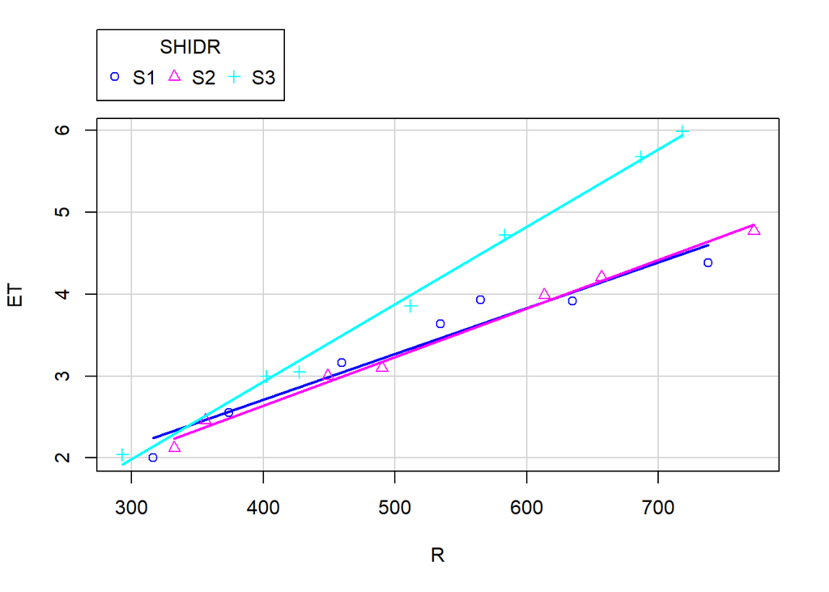

```r
scatterplot(ET~R|SHIDR,smooth=F,data=dd)
```

```r
(slopes <- emtrends (mod4, ~SHIDR, var = "R"))
```

```
##  SHIDR R.trend       SE df lower.CL upper.CL
##  S1    0.00559 0.000428 15  0.00468  0.00651
##  S2    0.00593 0.000386 15  0.00511  0.00676
##  S3    0.00946 0.000404 15  0.00860  0.01032
##
## Confidence level used: 0.95
```

```r
pairs(slopes)
```

```
##  contrast  estimate       SE df t.ratio p.value
##  S1 - S2  -0.000339 0.000577 15 -0.588  0.8286
##  S1 - S3  -0.003866 0.000589 15 -6.565  <.0001
##  S2 - S3  -0.003527 0.000559 15 -6.308  <.0001
##
## P value adjustment: tukey method for comparing a family of 3 estimates
```

```r
emmeans(mod4,~SHIDR|R,at=list(R =390))
```

```
## R = 390:
##  SHIDR emmean     SE df lower.CL upper.CL
##  S1      2.66 0.0798 15     2.49     2.83
##  S2      2.58 0.0779 15     2.42     2.75
##  S3      2.84 0.0777 15     2.68     3.01
##
## Confidence level used: 0.95
```

```r
emm <- emmeans(mod4,~SHIDR|R,at=list(R = mean(dd$R)))
pairs(emm)
```

```
## R = 520:
##  contrast estimate     SE df t.ratio p.value
##  S1 - S2    0.0294 0.0824 15  0.357  0.9324
##  S1 - S3   -0.6890 0.0824 15 -8.365  <.0001
##  S2 - S3   -0.7184 0.0824 15 -8.721  <.0001
##
## P value adjustment: tukey method for comparing a family of 3 estimates
```

**Compareu els 4 models anteriors. Escolliu-ne el que us sembli millor.**

##### 21) calculem la variança de tots els models

##### 22) fem l’anova de mod3 amb mod4 i mirem pvalor

##### 23) Mirem quins tenen tots els efectes significatius emprant el test Anova. Després fem el qqplots per veure si és lineal i mirem l’scatter plot de $\hat{e}$ vs $\hat{y}$ per comprobar que hi hagi homocedasticitat

```r
summary(mod1)$sigma^2
```

```
## [1] 1.277803
```

```r
summary(mod2)$sigma^2
```

```
## [1] 0.2178304
```

```r
summary(mod3)$sigma^2
```

```
## [1] 0.09833104
```

```r
summary(mod4)$sigma^2
```

```
## [1] 0.02373696
```

```r
anova(mod4, mod3)
```

```
## Analysis of Variance Table
##
## Model 1: ET ~ SHIDR * R
## Model 2: ET ~ SHIDR + R
##   Res.Df     RSS Df Sum of Sq      F   Pr(>F)
## 1     15 0.35605
## 2     17 1.67163 -2   -1.3156 27.712 9.18e-06 ***
## ---
## Signif. codes:  0 '***' 0.001 '**' 0.01 '*' 0.05 '.' 0.1 ' ' 1
```

```r
Anova(mod1) #SHIDR no significatiu
```

```
## Anova Table (Type II tests)
##
## Response: ET
##            Sum Sq Df F value Pr(>F)
## SHIDR      2.1266  2  0.8321 0.4512
## Residuals 23.0005 18
```

```r
Anova(mod2) #Ni T ni SHIDR significatiu
```

```
## Anova Table (Type II tests)
##
## Response: ET
##           Sum Sq Df F value Pr(>F)
## T         0.0350  1  0.1608 0.6932
## R         0.0013  1  0.0058 0.9400
## Residuals 3.9209 18
```

```r
Anova(mod3) #Tot significatiu
```

```
## Anova Table (Type II tests)
##
## Response: ET
##            Sum Sq Df F value    Pr(>F)
## SHIDR      2.2843  2  11.616 0.0006607 ***
## R         21.3288  1 216.908 4.139e-11 ***
## Residuals  1.6716 17
## ---
## Signif. codes:  0 '***' 0.001 '**' 0.01 '*' 0.05 '.' 0.1 ' ' 1
```

```r
Anova(mod4) #Tot significatiu
```

```
## Anova Table (Type II tests)
##
## Response: ET
##            Sum Sq Df F value    Pr(>F)
## SHIDR      2.2843  2  48.118 2.978e-07 ***
## R         21.3288  1 898.549 8.414e-15 ***
## SHIDR:R    1.3156  2  27.712 9.180e-06 ***
## Residuals  0.3561 15
## ---
## Signif. codes:  0 '***' 0.001 '**' 0.01 '*' 0.05 '.' 0.1 ' ' 1
```

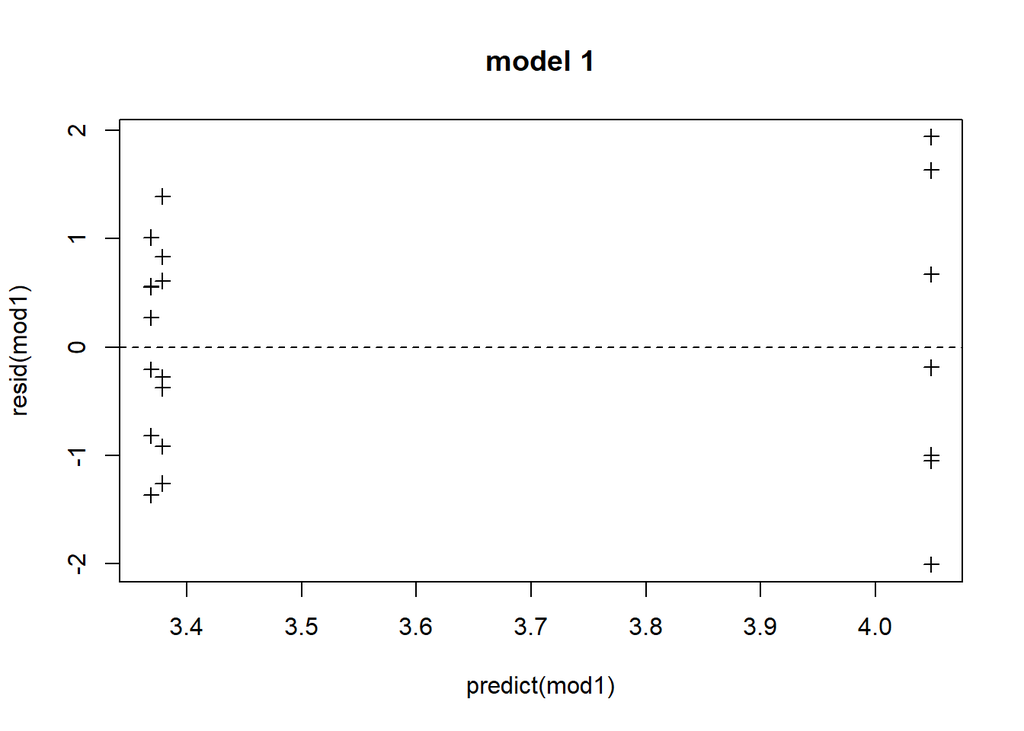

```r
plot(predict(mod1),resid(mod1),pch=3,main="model 1")
abline(h=0,lty=2)
```

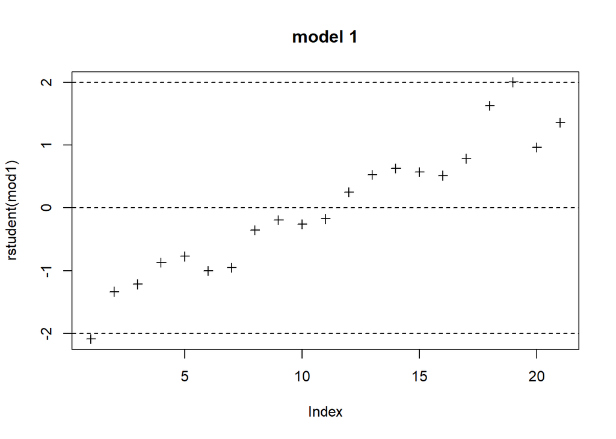

```r
plot(rstudent(mod1),pch=3,main="model 1")
abline(h=c(-3,-2,0,2,3),lty=2)
```

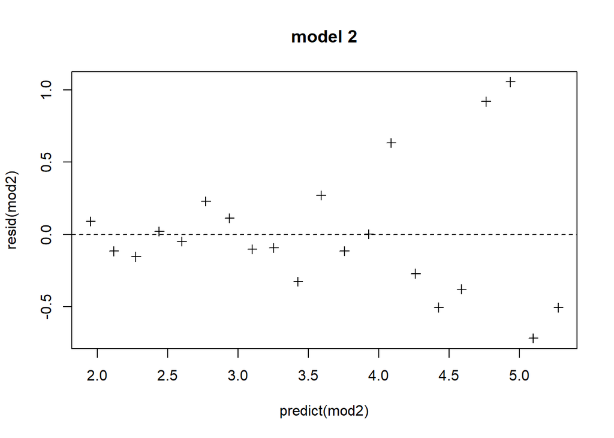

```r
plot(predict(mod2),resid(mod2),pch=3,main="model 2")
abline(h=0,lty=2)
```

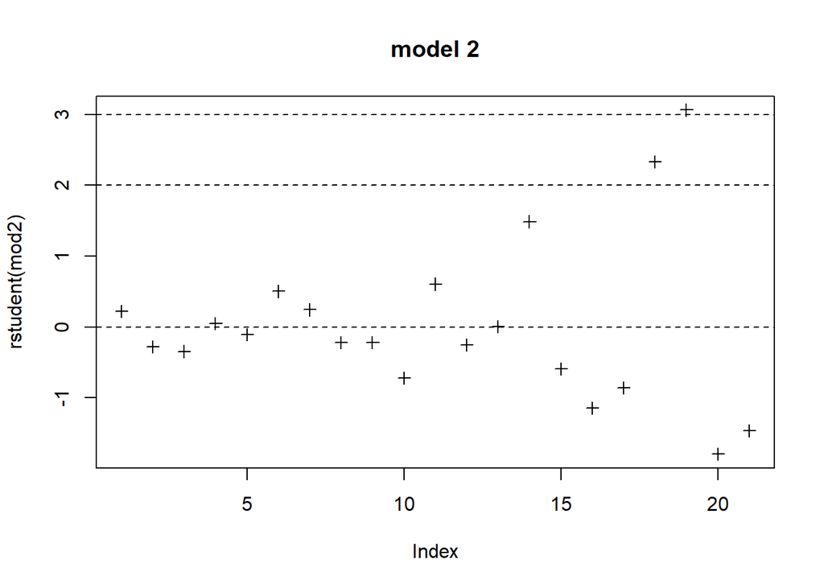

```r
plot(rstudent(mod2),pch=3,main="model 2")
abline(h=c(-3,-2,0,2,3),lty=2)
```

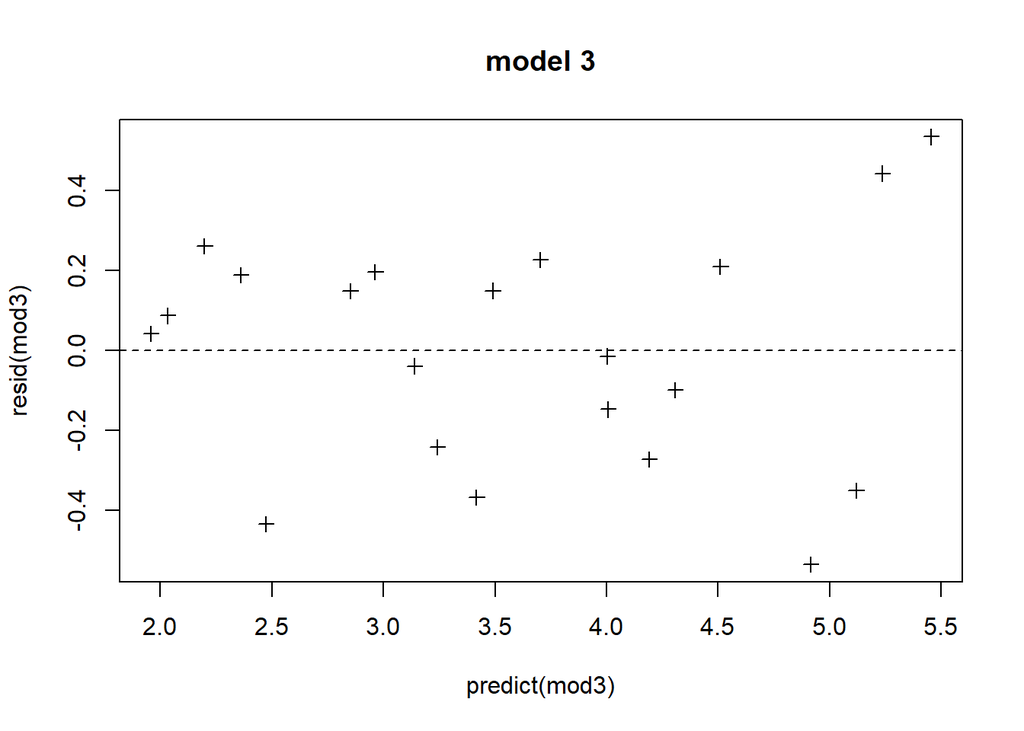

```r
plot(predict(mod3),resid(mod3),pch=3,main="model 3")
abline(h=0,lty=2)
```

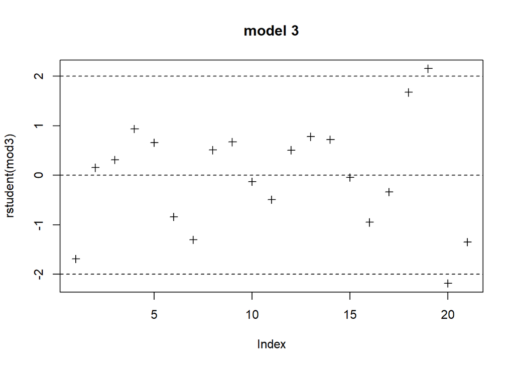

```r
plot(rstudent(mod3),pch=3,main="model 3")
abline(h=c(-3,-2,0,2,3),lty=2)
```

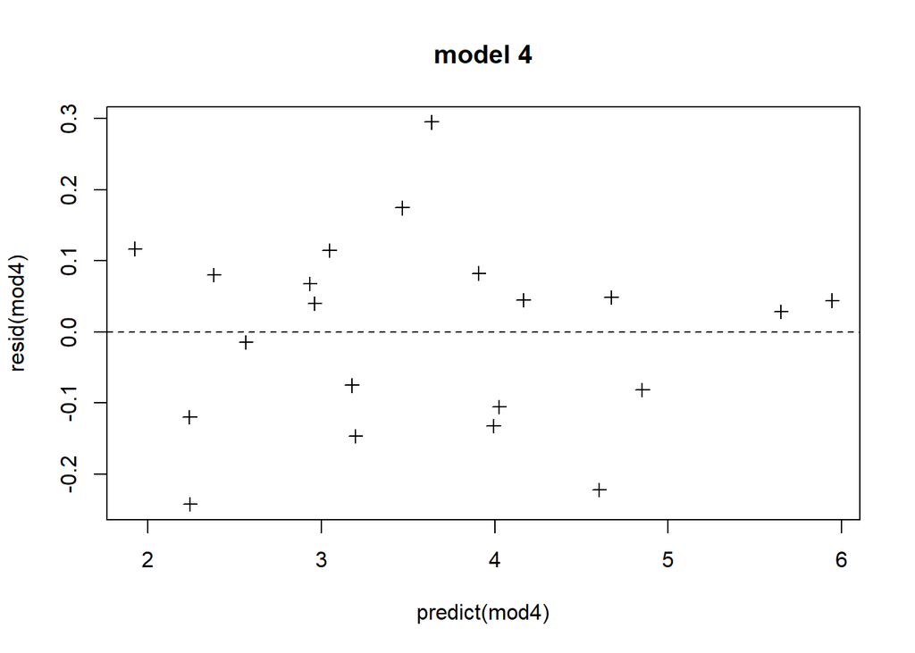

```r
plot(predict(mod4),resid(mod4),pch=3,main="model 4")
abline(h=0,lty=2)
```

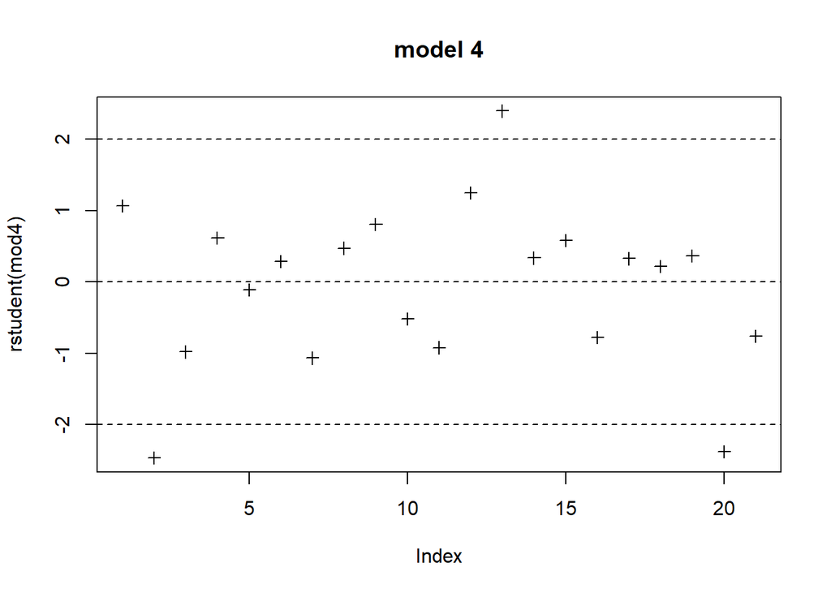

```r
plot(rstudent(mod4),pch=3,main="model 4")
abline(h=c(-3,-2,0,2,3),lty=2)
```

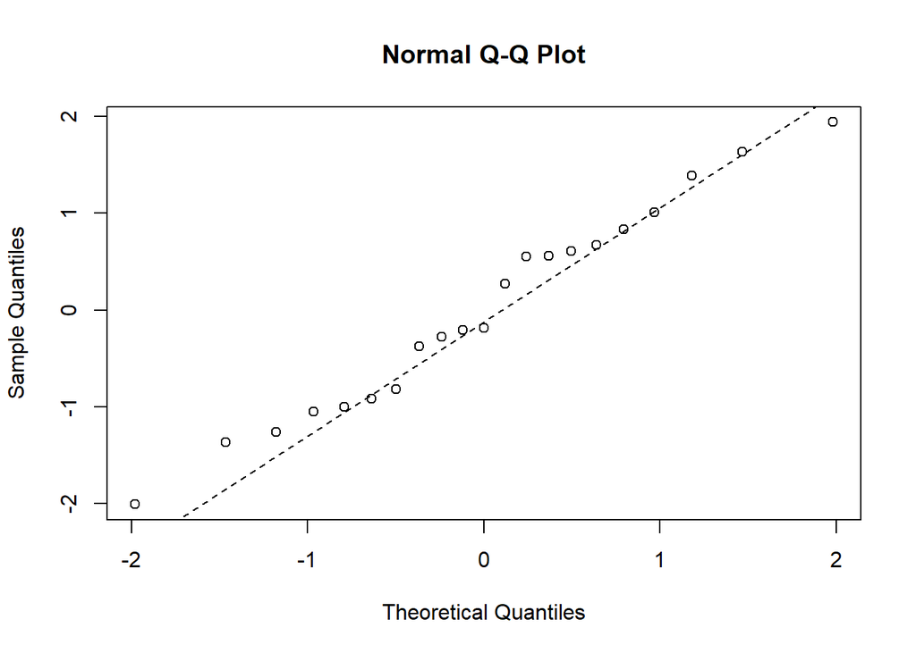

```r
qqnorm(resid(mod1))
qqline(resid(mod1), lt = 2)
```

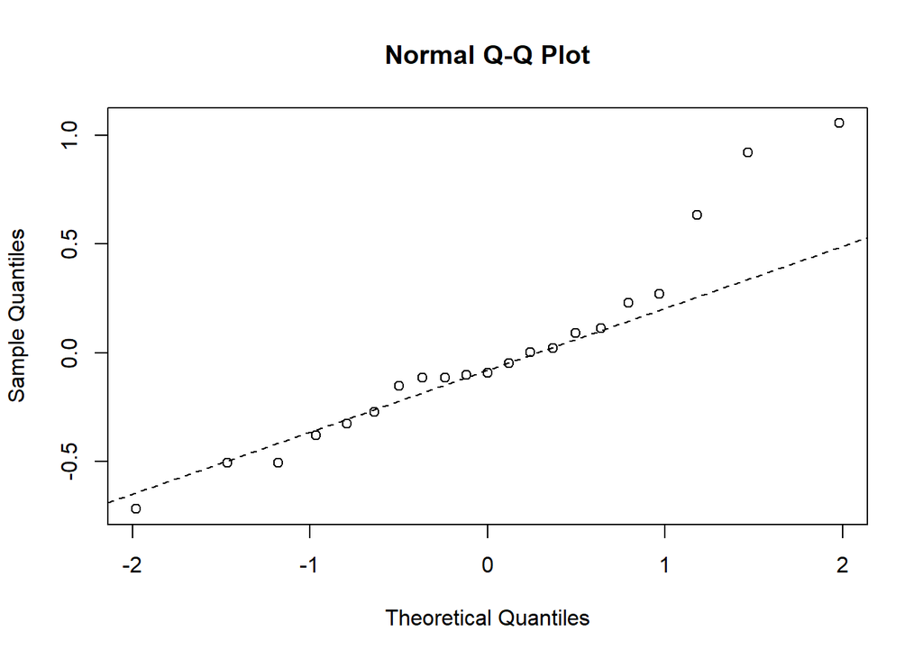

```r
qqnorm(resid(mod2))
qqline(resid(mod2), lt = 2) # no gaire
```

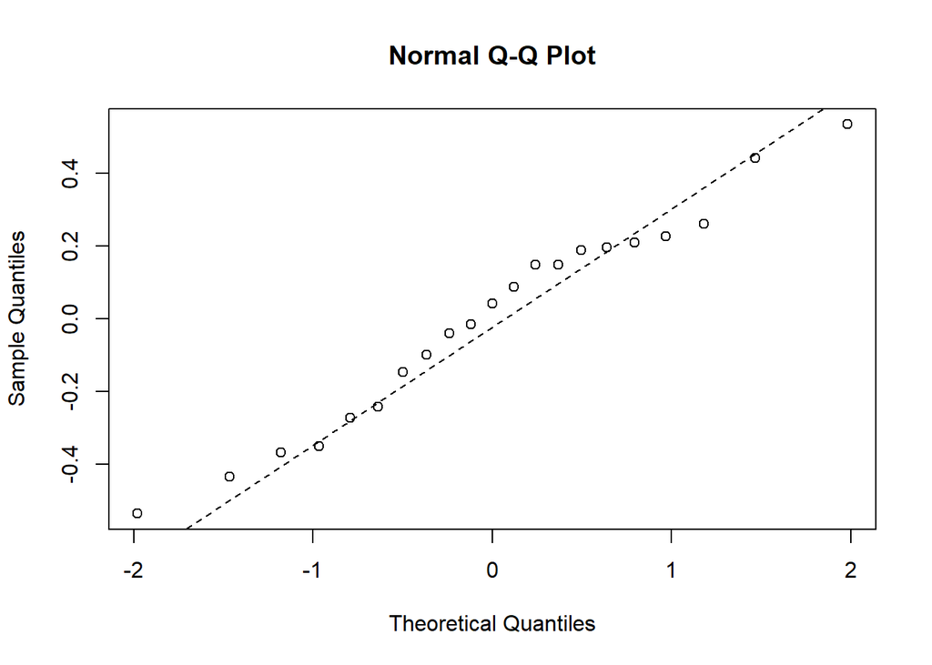

```r
qqnorm(resid(mod3))
qqline(resid(mod3), lt = 2)
```

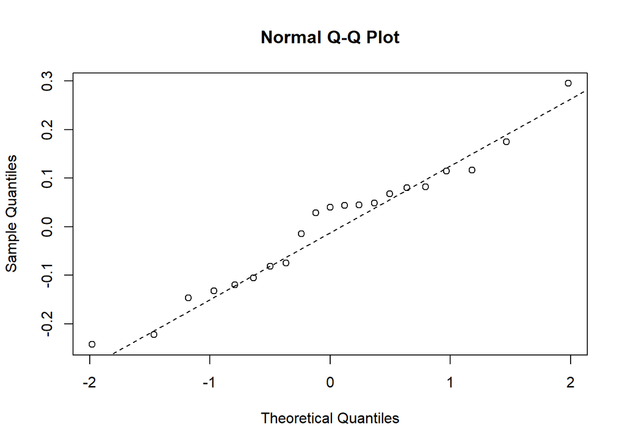

```r
qqnorm(resid(mod4))
qqline(resid(mod4), lt = 2) # no gaire
```

##### 24) fem l’emmeans en R = 680

##### 25) fem pairs

```r
(emm2 <- emmeans(mod3,~SHIDR|R,at= list(R=680)))
```

```
## R = 680:
##  SHIDR emmean    SE df lower.CL upper.CL
##  S1      4.51 0.142 17     4.21     4.81
##  S2      4.47 0.140 17     4.18     4.77
##  S3      5.19 0.142 17     4.89     5.49
##
## Confidence level used: 0.95
```

```r
pairs(emm2)
```

```
## R = 680:
##  contrast estimate    SE df t.ratio p.value
##  S1 - S2    0.0375 0.168 17  0.224  0.9729
##  S1 - S3   -0.6802 0.168 17 -4.058  0.0022
##  S2 - S3   -0.7177 0.168 17 -4.281  0.0014
##
## P value adjustment: tukey method for comparing a family of 3 estimates
```

```r
CLD(emm2)
```

```
## R = 680:
##  SHIDR emmean    SE df lower.CL upper.CL .group
##  S2      4.47 0.140 17     4.18     4.77  1
##  S1      4.51 0.142 17     4.21     4.81  1
##  S3      5.19 0.142 17     4.89     5.49   2
##
## Confidence level used: 0.95
## P value adjustment: tukey method for comparing a family of 3 estimates
## significance level used: alpha = 0.05
```

```r
emm3 <- emmeans(mod3,~SHIDR|R)
pairs(emm3)
```

```
## R = 520:
##  contrast estimate    SE df t.ratio p.value
##  S1 - S2    0.0375 0.168 17  0.224  0.9729
##  S1 - S3   -0.6802 0.168 17 -4.058  0.0022
##  S2 - S3   -0.7177 0.168 17 -4.281  0.0014
##
## P value adjustment: tukey method for comparing a family of 3 estimates
```

```r
CLD(emm3)
```

```
## R = 520:
##  SHIDR emmean    SE df lower.CL upper.CL .group
##  S2      3.35 0.119 17     3.10     3.60  1
##  S1      3.38 0.119 17     3.13     3.63  1
##  S3      4.06 0.119 17     3.81     4.31   2
##
## Confidence level used: 0.95
## P value adjustment: tukey method for comparing a family of 3 estimates
## significance level used: alpha = 0.05
```